# Risk Factor Analysis

## Outcome Variable

**Outcome Variable:** wasted

## Predictor Variables

**Intervention Variable:** nchldlt5

**Adjustment Set:**

- arm
- W_mage
- meducyrs
- feducyrs
- hhwealth_quart
- hfoodsec
- W_mhtcm
- W_nrooms
- W_parity
- impfloor
- impsan
- safeh20
- delta_W_mage
- delta_meducyrs
- delta_feducyrs
- delta_hhwealth_quart
- delta_hfoodsec
- delta_W_mhtcm
- delta_W_nrooms
- delta_W_parity
- delta_impfloor
- delta_impsan
- delta_safeh20

## Stratifying Variables

The analysis was stratified on these variable(s):

- agecat
- studyid
- country

## Data Summary

| agecat | studyid | country | nchldlt5 | wasted | n_cell | n |
| --- | --- | --- | --- | --- | --- | --- |
| Birth | ki1000108-IRC | INDIA | 1 | 0 | 50 | 343 |
| Birth | ki1000108-IRC | INDIA | 1 | 1 | 22 | 343 |
| Birth | ki1000108-IRC | INDIA | 2+ | 0 | 201 | 343 |
| Birth | ki1000108-IRC | INDIA | 2+ | 1 | 70 | 343 |
| Birth | ki1017093c-NIH-Crypto | BANGLADESH | 1 | 0 | 12 | 23 |
| Birth | ki1017093c-NIH-Crypto | BANGLADESH | 1 | 1 | 3 | 23 |
| Birth | ki1017093c-NIH-Crypto | BANGLADESH | 2+ | 0 | 8 | 23 |
| Birth | ki1017093c-NIH-Crypto | BANGLADESH | 2+ | 1 | 0 | 23 |
| Birth | kiGH5241-JiVitA-3 | BANGLADESH | 1 | 0 | 8410 | 15688 |
| Birth | kiGH5241-JiVitA-3 | BANGLADESH | 1 | 1 | 974 | 15688 |
| Birth | kiGH5241-JiVitA-3 | BANGLADESH | 2+ | 0 | 5772 | 15688 |
| Birth | kiGH5241-JiVitA-3 | BANGLADESH | 2+ | 1 | 532 | 15688 |
| 6 months | ki1000108-IRC | INDIA | 1 | 0 | 77 | 408 |
| 6 months | ki1000108-IRC | INDIA | 1 | 1 | 11 | 408 |
| 6 months | ki1000108-IRC | INDIA | 2+ | 0 | 277 | 408 |
| 6 months | ki1000108-IRC | INDIA | 2+ | 1 | 43 | 408 |
| 6 months | ki1017093b-PROVIDE | BANGLADESH | 1 | 0 | 409 | 582 |
| 6 months | ki1017093b-PROVIDE | BANGLADESH | 1 | 1 | 17 | 582 |
| 6 months | ki1017093b-PROVIDE | BANGLADESH | 2+ | 0 | 149 | 582 |
| 6 months | ki1017093b-PROVIDE | BANGLADESH | 2+ | 1 | 7 | 582 |
| 6 months | ki1017093c-NIH-Crypto | BANGLADESH | 1 | 0 | 494 | 715 |
| 6 months | ki1017093c-NIH-Crypto | BANGLADESH | 1 | 1 | 13 | 715 |
| 6 months | ki1017093c-NIH-Crypto | BANGLADESH | 2+ | 0 | 200 | 715 |
| 6 months | ki1017093c-NIH-Crypto | BANGLADESH | 2+ | 1 | 8 | 715 |
| 6 months | ki1066203-TanzaniaChild2 | TANZANIA, UNITED REPUBLIC OF | 1 | 0 | 1335 | 2019 |
| 6 months | ki1066203-TanzaniaChild2 | TANZANIA, UNITED REPUBLIC OF | 1 | 1 | 55 | 2019 |
| 6 months | ki1066203-TanzaniaChild2 | TANZANIA, UNITED REPUBLIC OF | 2+ | 0 | 597 | 2019 |
| 6 months | ki1066203-TanzaniaChild2 | TANZANIA, UNITED REPUBLIC OF | 2+ | 1 | 32 | 2019 |
| 6 months | ki1148112-LCNI-5 | MALAWI | 1 | 0 | 384 | 811 |
| 6 months | ki1148112-LCNI-5 | MALAWI | 1 | 1 | 6 | 811 |
| 6 months | ki1148112-LCNI-5 | MALAWI | 2+ | 0 | 413 | 811 |
| 6 months | ki1148112-LCNI-5 | MALAWI | 2+ | 1 | 8 | 811 |
| 6 months | kiGH5241-JiVitA-3 | BANGLADESH | 1 | 0 | 9976 | 16773 |
| 6 months | kiGH5241-JiVitA-3 | BANGLADESH | 1 | 1 | 896 | 16773 |
| 6 months | kiGH5241-JiVitA-3 | BANGLADESH | 2+ | 0 | 5378 | 16773 |
| 6 months | kiGH5241-JiVitA-3 | BANGLADESH | 2+ | 1 | 523 | 16773 |
| 24 months | ki1000108-IRC | INDIA | 1 | 0 | 78 | 409 |
| 24 months | ki1000108-IRC | INDIA | 1 | 1 | 11 | 409 |
| 24 months | ki1000108-IRC | INDIA | 2+ | 0 | 300 | 409 |
| 24 months | ki1000108-IRC | INDIA | 2+ | 1 | 20 | 409 |
| 24 months | ki1017093b-PROVIDE | BANGLADESH | 1 | 0 | 375 | 578 |
| 24 months | ki1017093b-PROVIDE | BANGLADESH | 1 | 1 | 48 | 578 |
| 24 months | ki1017093b-PROVIDE | BANGLADESH | 2+ | 0 | 138 | 578 |
| 24 months | ki1017093b-PROVIDE | BANGLADESH | 2+ | 1 | 17 | 578 |
| 24 months | ki1017093c-NIH-Crypto | BANGLADESH | 1 | 0 | 328 | 514 |
| 24 months | ki1017093c-NIH-Crypto | BANGLADESH | 1 | 1 | 29 | 514 |
| 24 months | ki1017093c-NIH-Crypto | BANGLADESH | 2+ | 0 | 141 | 514 |
| 24 months | ki1017093c-NIH-Crypto | BANGLADESH | 2+ | 1 | 16 | 514 |
| 24 months | ki1066203-TanzaniaChild2 | TANZANIA, UNITED REPUBLIC OF | 1 | 0 | 5 | 6 |
| 24 months | ki1066203-TanzaniaChild2 | TANZANIA, UNITED REPUBLIC OF | 1 | 1 | 0 | 6 |
| 24 months | ki1066203-TanzaniaChild2 | TANZANIA, UNITED REPUBLIC OF | 2+ | 0 | 1 | 6 |
| 24 months | ki1066203-TanzaniaChild2 | TANZANIA, UNITED REPUBLIC OF | 2+ | 1 | 0 | 6 |
| 24 months | ki1148112-LCNI-5 | MALAWI | 1 | 0 | 271 | 555 |
| 24 months | ki1148112-LCNI-5 | MALAWI | 1 | 1 | 6 | 555 |
| 24 months | ki1148112-LCNI-5 | MALAWI | 2+ | 0 | 274 | 555 |
| 24 months | ki1148112-LCNI-5 | MALAWI | 2+ | 1 | 4 | 555 |
| 24 months | kiGH5241-JiVitA-3 | BANGLADESH | 1 | 0 | 4203 | 8593 |
| 24 months | kiGH5241-JiVitA-3 | BANGLADESH | 1 | 1 | 1231 | 8593 |
| 24 months | kiGH5241-JiVitA-3 | BANGLADESH | 2+ | 0 | 2516 | 8593 |
| 24 months | kiGH5241-JiVitA-3 | BANGLADESH | 2+ | 1 | 643 | 8593 |

The following strata were considered:

- agecat: 24 months, studyid: ki1000108-IRC, country: INDIA
- agecat: 24 months, studyid: ki1017093b-PROVIDE, country: BANGLADESH
- agecat: 24 months, studyid: ki1017093c-NIH-Crypto, country: BANGLADESH
- agecat: 24 months, studyid: ki1066203-TanzaniaChild2, country: TANZANIA, UNITED REPUBLIC OF
- agecat: 24 months, studyid: ki1148112-LCNI-5, country: MALAWI
- agecat: 24 months, studyid: kiGH5241-JiVitA-3, country: BANGLADESH
- agecat: 6 months, studyid: ki1000108-IRC, country: INDIA
- agecat: 6 months, studyid: ki1017093b-PROVIDE, country: BANGLADESH
- agecat: 6 months, studyid: ki1017093c-NIH-Crypto, country: BANGLADESH
- agecat: 6 months, studyid: ki1066203-TanzaniaChild2, country: TANZANIA, UNITED REPUBLIC OF
- agecat: 6 months, studyid: ki1148112-LCNI-5, country: MALAWI
- agecat: 6 months, studyid: kiGH5241-JiVitA-3, country: BANGLADESH
- agecat: Birth, studyid: ki1000108-IRC, country: INDIA
- agecat: Birth, studyid: ki1017093c-NIH-Crypto, country: BANGLADESH
- agecat: Birth, studyid: kiGH5241-JiVitA-3, country: BANGLADESH

### Dropped Strata

Some strata were dropped due to rare outcomes:

- agecat: Birth, studyid: ki1017093c-NIH-Crypto, country: BANGLADESH
- agecat: 24 months, studyid: ki1066203-TanzaniaChild2, country: TANZANIA, UNITED REPUBLIC OF
- agecat: 24 months, studyid: ki1148112-LCNI-5, country: MALAWI

## Methods Detail

We’re interested in the causal parameters $E[Y_a]$ for all values of $a \in \mathcal{A}$. These parameters represent the mean outcome if, possibly contrary to fact, we intervened to set all units to have $A=a$. Under the randomization and positivity assumptions, these are identified by the statistical parameters $\psi_a=E_W[E_{Y|A,W}(Y|A=a,W)]$. In addition, we’re interested in the mean of $Y$, $E[Y]$ under no intervention (the observed mean). We will estimate these parameters by using SuperLearner to fit the relevant likelihood factors – $E_{Y|A,W}(Y|A=a,W)$ and $p(A=a|W)$, and then updating our likelihood fit using a joint TMLE.

For unadjusted analyses ($W=\{\}$), initial likelihoods were estimated using Lrnr_glm to estimate the simple $E(Y|A)$ and Lrnr_mean to estimate $p(A)$. For adjusted analyses, a small library containing Lrnr_glmnet, Lrnr_xgboost, and Lrnr_mean was used.

Having estimated these parameters, we will then use the delta method to estimate relative risks and attributable risks relative to a prespecified baseline level of $A$.

# Results Detail

## Results Plots

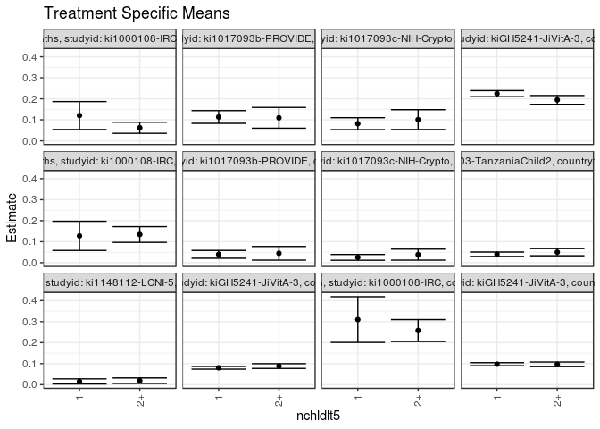

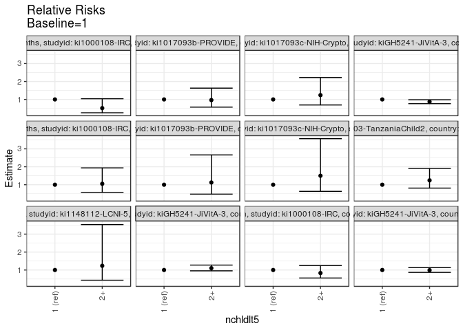

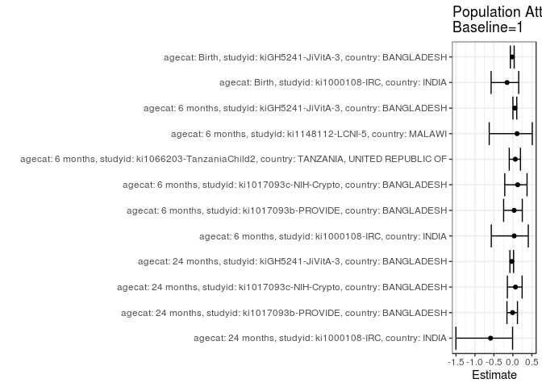

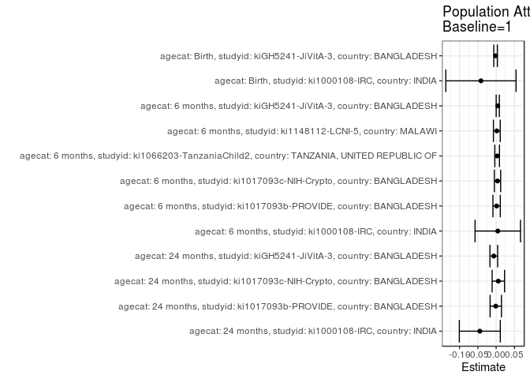

## Results Table

### Parameter: TSM

| agecat | studyid | country | intervention_level | baseline_level | estimate | ci_lower | ci_upper |
| --- | --- | --- | --- | --- | --- | --- | --- |
| Birth | ki1000108-IRC | INDIA | 1 | NA | 0.3097460 | 0.2008876 | 0.4186043 |
| Birth | ki1000108-IRC | INDIA | 2+ | NA | 0.2575374 | 0.2052692 | 0.3098056 |
| Birth | kiGH5241-JiVitA-3 | BANGLADESH | 1 | NA | 0.0975163 | 0.0904245 | 0.1046082 |
| Birth | kiGH5241-JiVitA-3 | BANGLADESH | 2+ | NA | 0.0966531 | 0.0857633 | 0.1075429 |
| 6 months | ki1000108-IRC | INDIA | 1 | NA | 0.1278481 | 0.0582741 | 0.1974220 |
| 6 months | ki1000108-IRC | INDIA | 2+ | NA | 0.1344123 | 0.0969602 | 0.1718643 |
| 6 months | ki1017093b-PROVIDE | BANGLADESH | 1 | NA | 0.0399061 | 0.0213027 | 0.0585095 |
| 6 months | ki1017093b-PROVIDE | BANGLADESH | 2+ | NA | 0.0448718 | 0.0123573 | 0.0773863 |
| 6 months | ki1017093c-NIH-Crypto | BANGLADESH | 1 | NA | 0.0256410 | 0.0118729 | 0.0394092 |
| 6 months | ki1017093c-NIH-Crypto | BANGLADESH | 2+ | NA | 0.0384615 | 0.0123088 | 0.0646143 |
| 6 months | ki1066203-TanzaniaChild2 | TANZANIA, UNITED REPUBLIC OF | 1 | NA | 0.0403713 | 0.0298974 | 0.0508453 |
| 6 months | ki1066203-TanzaniaChild2 | TANZANIA, UNITED REPUBLIC OF | 2+ | NA | 0.0502246 | 0.0331978 | 0.0672515 |
| 6 months | ki1148112-LCNI-5 | MALAWI | 1 | NA | 0.0153846 | 0.0031621 | 0.0276071 |
| 6 months | ki1148112-LCNI-5 | MALAWI | 2+ | NA | 0.0190024 | 0.0059523 | 0.0320524 |
| 6 months | kiGH5241-JiVitA-3 | BANGLADESH | 1 | NA | 0.0801391 | 0.0736738 | 0.0866044 |
| 6 months | kiGH5241-JiVitA-3 | BANGLADESH | 2+ | NA | 0.0883779 | 0.0770875 | 0.0996683 |
| 24 months | ki1000108-IRC | INDIA | 1 | NA | 0.1204164 | 0.0539281 | 0.1869046 |
| 24 months | ki1000108-IRC | INDIA | 2+ | NA | 0.0620918 | 0.0356383 | 0.0885453 |
| 24 months | ki1017093b-PROVIDE | BANGLADESH | 1 | NA | 0.1134494 | 0.0831800 | 0.1437189 |
| 24 months | ki1017093b-PROVIDE | BANGLADESH | 2+ | NA | 0.1094033 | 0.0600199 | 0.1587867 |
| 24 months | ki1017093c-NIH-Crypto | BANGLADESH | 1 | NA | 0.0815230 | 0.0531102 | 0.1099357 |
| 24 months | ki1017093c-NIH-Crypto | BANGLADESH | 2+ | NA | 0.1009986 | 0.0538024 | 0.1481948 |
| 24 months | kiGH5241-JiVitA-3 | BANGLADESH | 1 | NA | 0.2244865 | 0.2100353 | 0.2389378 |
| 24 months | kiGH5241-JiVitA-3 | BANGLADESH | 2+ | NA | 0.1946625 | 0.1737335 | 0.2155915 |

### Parameter: E(Y)

| agecat | studyid | country | intervention_level | baseline_level | estimate | ci_lower | ci_upper |
| --- | --- | --- | --- | --- | --- | --- | --- |
| Birth | ki1000108-IRC | INDIA | NA | NA | 0.2682216 | 0.2212677 | 0.3151755 |
| Birth | kiGH5241-JiVitA-3 | BANGLADESH | NA | NA | 0.0959969 | 0.0907923 | 0.1012016 |
| 6 months | ki1000108-IRC | INDIA | NA | NA | 0.1323529 | 0.0994307 | 0.1652752 |
| 6 months | ki1017093b-PROVIDE | BANGLADESH | NA | NA | 0.0412371 | 0.0250690 | 0.0574052 |
| 6 months | ki1017093c-NIH-Crypto | BANGLADESH | NA | NA | 0.0293706 | 0.0169860 | 0.0417552 |
| 6 months | ki1066203-TanzaniaChild2 | TANZANIA, UNITED REPUBLIC OF | NA | NA | 0.0430906 | 0.0342310 | 0.0519502 |
| 6 months | ki1148112-LCNI-5 | MALAWI | NA | NA | 0.0172626 | 0.0082929 | 0.0262323 |
| 6 months | kiGH5241-JiVitA-3 | BANGLADESH | NA | NA | 0.0846003 | 0.0797949 | 0.0894056 |
| 24 months | ki1000108-IRC | INDIA | NA | NA | 0.0757946 | 0.0501131 | 0.1014762 |
| 24 months | ki1017093b-PROVIDE | BANGLADESH | NA | NA | 0.1124567 | 0.0866788 | 0.1382347 |
| 24 months | ki1017093c-NIH-Crypto | BANGLADESH | NA | NA | 0.0875486 | 0.0630907 | 0.1120065 |
| 24 months | kiGH5241-JiVitA-3 | BANGLADESH | NA | NA | 0.2180845 | 0.2082032 | 0.2279658 |

### Parameter: RR

| agecat | studyid | country | intervention_level | baseline_level | estimate | ci_lower | ci_upper |
| --- | --- | --- | --- | --- | --- | --- | --- |
| Birth | ki1000108-IRC | INDIA | 1 | 1 | 1.0000000 | 1.0000000 | 1.0000000 |
| Birth | ki1000108-IRC | INDIA | 2+ | 1 | 0.8314471 | 0.5538522 | 1.2481746 |
| Birth | kiGH5241-JiVitA-3 | BANGLADESH | 1 | 1 | 1.0000000 | 1.0000000 | 1.0000000 |
| Birth | kiGH5241-JiVitA-3 | BANGLADESH | 2+ | 1 | 0.9911482 | 0.8684299 | 1.1312079 |
| 6 months | ki1000108-IRC | INDIA | 1 | 1 | 1.0000000 | 1.0000000 | 1.0000000 |
| 6 months | ki1000108-IRC | INDIA | 2+ | 1 | 1.0513439 | 0.5702214 | 1.9384119 |
| 6 months | ki1017093b-PROVIDE | BANGLADESH | 1 | 1 | 1.0000000 | 1.0000000 | 1.0000000 |
| 6 months | ki1017093b-PROVIDE | BANGLADESH | 2+ | 1 | 1.1244344 | 0.4750499 | 2.6615154 |
| 6 months | ki1017093c-NIH-Crypto | BANGLADESH | 1 | 1 | 1.0000000 | 1.0000000 | 1.0000000 |
| 6 months | ki1017093c-NIH-Crypto | BANGLADESH | 2+ | 1 | 1.5000000 | 0.6306811 | 3.5675717 |
| 6 months | ki1066203-TanzaniaChild2 | TANZANIA, UNITED REPUBLIC OF | 1 | 1 | 1.0000000 | 1.0000000 | 1.0000000 |
| 6 months | ki1066203-TanzaniaChild2 | TANZANIA, UNITED REPUBLIC OF | 2+ | 1 | 1.2440668 | 0.8115927 | 1.9069937 |
| 6 months | ki1148112-LCNI-5 | MALAWI | 1 | 1 | 1.0000000 | 1.0000000 | 1.0000000 |
| 6 months | ki1148112-LCNI-5 | MALAWI | 2+ | 1 | 1.2351544 | 0.4321632 | 3.5301627 |
| 6 months | kiGH5241-JiVitA-3 | BANGLADESH | 1 | 1 | 1.0000000 | 1.0000000 | 1.0000000 |
| 6 months | kiGH5241-JiVitA-3 | BANGLADESH | 2+ | 1 | 1.1028062 | 0.9540494 | 1.2747573 |
| 24 months | ki1000108-IRC | INDIA | 1 | 1 | 1.0000000 | 1.0000000 | 1.0000000 |
| 24 months | ki1000108-IRC | INDIA | 2+ | 1 | 0.5156427 | 0.2560073 | 1.0385930 |
| 24 months | ki1017093b-PROVIDE | BANGLADESH | 1 | 1 | 1.0000000 | 1.0000000 | 1.0000000 |
| 24 months | ki1017093b-PROVIDE | BANGLADESH | 2+ | 1 | 0.9643355 | 0.5707177 | 1.6294272 |
| 24 months | ki1017093c-NIH-Crypto | BANGLADESH | 1 | 1 | 1.0000000 | 1.0000000 | 1.0000000 |
| 24 months | ki1017093c-NIH-Crypto | BANGLADESH | 2+ | 1 | 1.2388975 | 0.6914128 | 2.2198998 |
| 24 months | kiGH5241-JiVitA-3 | BANGLADESH | 1 | 1 | 1.0000000 | 1.0000000 | 1.0000000 |
| 24 months | kiGH5241-JiVitA-3 | BANGLADESH | 2+ | 1 | 0.8671456 | 0.7650843 | 0.9828218 |

### Parameter: PAR

| agecat | studyid | country | intervention_level | baseline_level | estimate | ci_lower | ci_upper |
| --- | --- | --- | --- | --- | --- | --- | --- |
| Birth | ki1000108-IRC | INDIA | 1 | NA | -0.0415244 | -0.1375011 | 0.0544523 |
| Birth | kiGH5241-JiVitA-3 | BANGLADESH | 1 | NA | -0.0015194 | -0.0064121 | 0.0033733 |
| 6 months | ki1000108-IRC | INDIA | 1 | NA | 0.0045049 | -0.0575782 | 0.0665879 |
| 6 months | ki1017093b-PROVIDE | BANGLADESH | 1 | NA | 0.0013310 | -0.0087115 | 0.0113735 |
| 6 months | ki1017093c-NIH-Crypto | BANGLADESH | 1 | NA | 0.0037296 | -0.0048790 | 0.0123382 |
| 6 months | ki1066203-TanzaniaChild2 | TANZANIA, UNITED REPUBLIC OF | 1 | NA | 0.0027193 | -0.0036554 | 0.0090940 |
| 6 months | ki1148112-LCNI-5 | MALAWI | 1 | NA | 0.0018780 | -0.0074045 | 0.0111606 |
| 6 months | kiGH5241-JiVitA-3 | BANGLADESH | 1 | NA | 0.0044612 | 0.0001531 | 0.0087692 |
| 24 months | ki1000108-IRC | INDIA | 1 | NA | -0.0446217 | -0.1005988 | 0.0113554 |
| 24 months | ki1017093b-PROVIDE | BANGLADESH | 1 | NA | -0.0009927 | -0.0165131 | 0.0145277 |
| 24 months | ki1017093c-NIH-Crypto | BANGLADESH | 1 | NA | 0.0060256 | -0.0109349 | 0.0229862 |
| 24 months | kiGH5241-JiVitA-3 | BANGLADESH | 1 | NA | -0.0064020 | -0.0169174 | 0.0041133 |

### Parameter: PAF

| agecat | studyid | country | intervention_level | baseline_level | estimate | ci_lower | ci_upper |
| --- | --- | --- | --- | --- | --- | --- | --- |
| Birth | ki1000108-IRC | INDIA | 1 | NA | -0.1548138 | -0.5738958 | 0.1526789 |
| Birth | kiGH5241-JiVitA-3 | BANGLADESH | 1 | NA | -0.0158275 | -0.0681154 | 0.0339008 |
| 6 months | ki1000108-IRC | INDIA | 1 | NA | 0.0340369 | -0.5696308 | 0.4055388 |
| 6 months | ki1017093b-PROVIDE | BANGLADESH | 1 | NA | 0.0322770 | -0.2442495 | 0.2473473 |
| 6 months | ki1017093c-NIH-Crypto | BANGLADESH | 1 | NA | 0.1269841 | -0.2148048 | 0.3726097 |
| 6 months | ki1066203-TanzaniaChild2 | TANZANIA, UNITED REPUBLIC OF | 1 | NA | 0.0631068 | -0.0965466 | 0.1995153 |
| 6 months | ki1148112-LCNI-5 | MALAWI | 1 | NA | 0.1087912 | -0.6240960 | 0.5109568 |
| 6 months | kiGH5241-JiVitA-3 | BANGLADESH | 1 | NA | 0.0527321 | 0.0003123 | 0.1024033 |
| 24 months | ki1000108-IRC | INDIA | 1 | NA | -0.5887191 | -1.5023110 | -0.0086789 |
| 24 months | ki1017093b-PROVIDE | BANGLADESH | 1 | NA | -0.0088274 | -0.1567115 | 0.1201500 |
| 24 months | ki1017093c-NIH-Crypto | BANGLADESH | 1 | NA | 0.0688263 | -0.1454570 | 0.2430231 |
| 24 months | kiGH5241-JiVitA-3 | BANGLADESH | 1 | NA | -0.0293557 | -0.0787347 | 0.0177630 |